# STAT425_CS2_V1

Debapratim Ghosh, Shantanu Solanki

12/1/2021

## Problem Statement

In this case study, we are going to work with a study of crime rates in 47 states of the USE in 1960. The variables we have available are:

`M` - percentage of males aged 14–24 in total state population  
`So` - indicator variable for a southern state  
`Ed` - mean years of schooling of the population aged 25 years or over  
`Po1` - per capita expenditure on police protection in 1960  
`Po2` - per capita expenditure on police protection in 1959  
`LF` - labour force participation rate of civilian urban males in the age group 14-24  
`M.F` - number of males per 100 females  
`Pop` - state population in 1960 in hundred thousand  
`NW` - percentage of nonwhites in the population  
`U1` - unemployment rate of urban males 14–24  
`U2` - unemployment rate of urban males 35–39  
`wealth` - median value of transferable assets or family income  
`Ineq` - income inequality: percentage of families earning below half the median income  
`Prob` - probability of imprisonment: ratio of number of commitments to number of offenses  
`Time` - average time in months served by offenders in state prisons before their first release  
`Crime` - crime rate: number of offenses per 100,000 population in 1960 Our goal is to find the “best” model to predict crime rate.

## Analysis Steps :

### Loading Required Libraries

```r
library(dplyr)
library(faraway)
library(lmtest)
library(MASS)

library(car)

library(Metrics)
library(leaps)
```

### Reading the data

Let us first read the data and go through the required columns :

```r
crime = read.table("crime.txt", header=TRUE)
head(crime)
```

```
##      M So   Ed  Po1  Po2    LF   M.F Pop   NW    U1  U2 Wealth Ineq     Prob
## 1 15.1  1  9.1  5.8  5.6 0.510  95.0  33 30.1 0.108 4.1   3940 26.1 0.084602
## 2 14.3  0 11.3 10.3  9.5 0.583 101.2  13 10.2 0.096 3.6   5570 19.4 0.029599
## 3 14.2  1  8.9  4.5  4.4 0.533  96.9  18 21.9 0.094 3.3   3180 25.0 0.083401
## 4 13.6  0 12.1 14.9 14.1 0.577  99.4 157  8.0 0.102 3.9   6730 16.7 0.015801
## 5 14.1  0 12.1 10.9 10.1 0.591  98.5  18  3.0 0.091 2.0   5780 17.4 0.041399
## 6 12.1  0 11.0 11.8 11.5 0.547  96.4  25  4.4 0.084 2.9   6890 12.6 0.034201
##      Time Crime
## 1 26.2011   791
## 2 25.2999  1635
## 3 24.3006   578
## 4 29.9012  1969
## 5 21.2998  1234
## 6 20.9995   682
```

Let’s look at a summary of the dataset :

```r
summary(crime)
```

```
##        M               So               Ed             Po1
##  Min.   :11.90   Min.   :0.0000   Min.   : 8.70   Min.   : 4.50
##  1st Qu.:13.00   1st Qu.:0.0000   1st Qu.: 9.75   1st Qu.: 6.25
##  Median :13.60   Median :0.0000   Median :10.80   Median : 7.80
##  Mean   :13.86   Mean   :0.3404   Mean   :10.56   Mean   : 8.50
##  3rd Qu.:14.60   3rd Qu.:1.0000   3rd Qu.:11.45   3rd Qu.:10.45
##  Max.   :17.70   Max.   :1.0000   Max.   :12.20   Max.   :16.60
##       Po2               LF              M.F              Pop
##  Min.   : 4.100   Min.   :0.4800   Min.   : 93.40   Min.   :  3.00
##  1st Qu.: 5.850   1st Qu.:0.5305   1st Qu.: 96.45   1st Qu.: 10.00
##  Median : 7.300   Median :0.5600   Median : 97.70   Median : 25.00
##  Mean   : 8.023   Mean   :0.5612   Mean   : 98.30   Mean   : 36.62
##  3rd Qu.: 9.700   3rd Qu.:0.5930   3rd Qu.: 99.20   3rd Qu.: 41.50
##  Max.   :15.700   Max.   :0.6410   Max.   :107.10   Max.   :168.00
##        NW              U1                U2            Wealth
##  Min.   : 0.20   Min.   :0.07000   Min.   :2.000   Min.   :2880
##  1st Qu.: 2.40   1st Qu.:0.08050   1st Qu.:2.750   1st Qu.:4595
##  Median : 7.60   Median :0.09200   Median :3.400   Median :5370
##  Mean   :10.11   Mean   :0.09547   Mean   :3.398   Mean   :5254
##  3rd Qu.:13.25   3rd Qu.:0.10400   3rd Qu.:3.850   3rd Qu.:5915
##  Max.   :42.30   Max.   :0.14200   Max.   :5.800   Max.   :6890
##       Ineq            Prob              Time           Crime
##  Min.   :12.60   Min.   :0.00690   Min.   :12.20   Min.   : 342.0
##  1st Qu.:16.55   1st Qu.:0.03270   1st Qu.:21.60   1st Qu.: 658.5
##  Median :17.60   Median :0.04210   Median :25.80   Median : 831.0
##  Mean   :19.40   Mean   :0.04709   Mean   :26.60   Mean   : 905.1
##  3rd Qu.:22.75   3rd Qu.:0.05445   3rd Qu.:30.45   3rd Qu.:1057.5
##  Max.   :27.60   Max.   :0.11980   Max.   :44.00   Max.   :1993.0
```

```r
str(crime)
```

```
## 'data.frame':    47 obs. of  16 variables:
##  $ M     : num  15.1 14.3 14.2 13.6 14.1 12.1 12.7 13.1 15.7 14 ...
##  $ So    : int  1 0 1 0 0 0 1 1 1 0 ...
##  $ Ed    : num  9.1 11.3 8.9 12.1 12.1 11 11.1 10.9 9 11.8 ...
##  $ Po1   : num  5.8 10.3 4.5 14.9 10.9 11.8 8.2 11.5 6.5 7.1 ...
##  $ Po2   : num  5.6 9.5 4.4 14.1 10.1 11.5 7.9 10.9 6.2 6.8 ...
##  $ LF    : num  0.51 0.583 0.533 0.577 0.591 0.547 0.519 0.542 0.553 0.632 ...
##  $ M.F   : num  95 101.2 96.9 99.4 98.5 ...
##  $ Pop   : int  33 13 18 157 18 25 4 50 39 7 ...
##  $ NW    : num  30.1 10.2 21.9 8 3 4.4 13.9 17.9 28.6 1.5 ...
##  $ U1    : num  0.108 0.096 0.094 0.102 0.091 0.084 0.097 0.079 0.081 0.1 ...
##  $ U2    : num  4.1 3.6 3.3 3.9 2 2.9 3.8 3.5 2.8 2.4 ...
##  $ Wealth: int  3940 5570 3180 6730 5780 6890 6200 4720 4210 5260 ...
##  $ Ineq  : num  26.1 19.4 25 16.7 17.4 12.6 16.8 20.6 23.9 17.4 ...
##  $ Prob  : num  0.0846 0.0296 0.0834 0.0158 0.0414 ...
##  $ Time  : num  26.2 25.3 24.3 29.9 21.3 ...
##  $ Crime : int  791 1635 578 1969 1234 682 963 1555 856 705 ...
```

All the variables in the dataset are numeric or integer.

### Fitting a full linear model with the entire dataset

In order to perform model diagnostics, we need to fit a linear model with all the predictors on the entire dataset.

```r
model.lm.full<-lm(Crime~.,data=crime)
summary(model.lm.full)
```

```
##
## Call:
## lm(formula = Crime ~ ., data = crime)
##
## Residuals:
##     Min      1Q  Median      3Q     Max
## -395.74  -98.09   -6.69  112.99  512.67
##
## Coefficients:
##               Estimate Std. Error t value Pr(>|t|)
## (Intercept) -5.984e+03  1.628e+03  -3.675 0.000893 ***
## M            8.783e+01  4.171e+01   2.106 0.043443 *
## So          -3.803e+00  1.488e+02  -0.026 0.979765
## Ed           1.883e+02  6.209e+01   3.033 0.004861 **
## Po1          1.928e+02  1.061e+02   1.817 0.078892 .
## Po2         -1.094e+02  1.175e+02  -0.931 0.358830
## LF          -6.638e+02  1.470e+03  -0.452 0.654654
## M.F          1.741e+01  2.035e+01   0.855 0.398995
## Pop         -7.330e-01  1.290e+00  -0.568 0.573845
## NW           4.204e+00  6.481e+00   0.649 0.521279
## U1          -5.827e+03  4.210e+03  -1.384 0.176238
## U2           1.678e+02  8.234e+01   2.038 0.050161 .
## Wealth       9.617e-02  1.037e-01   0.928 0.360754
## Ineq         7.067e+01  2.272e+01   3.111 0.003983 **
## Prob        -4.855e+03  2.272e+03  -2.137 0.040627 *
## Time        -3.479e+00  7.165e+00  -0.486 0.630708
## ---
## Signif. codes:  0 '***' 0.001 '**' 0.01 '*' 0.05 '.' 0.1 ' ' 1
##
## Residual standard error: 209.1 on 31 degrees of freedom
## Multiple R-squared:  0.8031, Adjusted R-squared:  0.7078
## F-statistic: 8.429 on 15 and 31 DF,  p-value: 3.539e-07
```

### Checking Multicolinearity

Lets check whether some predictors are linearly dependent on one another or not.

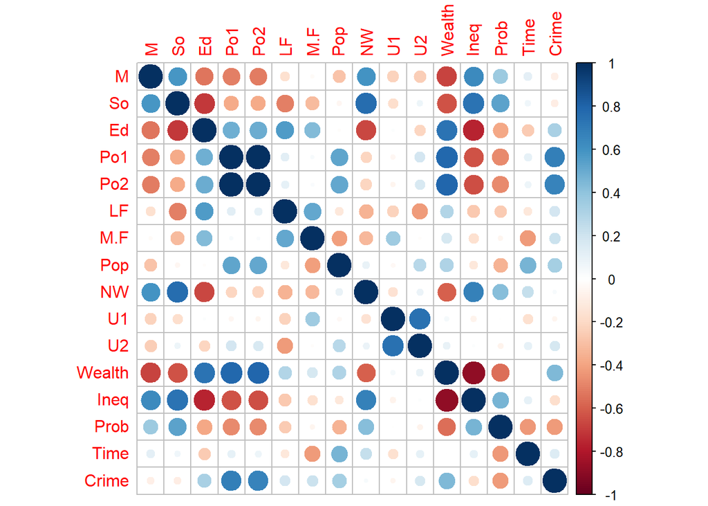

```r
library(corrplot)
mat<-cor(crime)
corrplot(mat, method="circle")
```

We can see that `Wealth` and `Ineq` are highly negatively correlated and similarly `Po1` and `Po2` are highly positively correlated .

Let’s check the presence of multicolinearity through VIF and Condition number

```r
model<-model.lm.full

x = model.matrix(model)[,-1]

x = x - matrix(apply(x,2, mean), dim(x)[1],dim(x)[2], byrow=TRUE)
x = x / matrix(apply(x, 2, sd), dim(x)[1],dim(x)[2], byrow=TRUE)
#Extracting the eigen-values:
e = eigen(t(x) %*% x)
sqrt(max(e$val)/min(e$val))
```

```
## [1] 36.11719
```

```r
vif(model)
```

```
##          M         So         Ed        Po1        Po2         LF        M.F
##   2.892448   5.342783   5.077447 104.658667 113.559262   3.712690   3.785934
##        Pop         NW         U1         U2     Wealth       Ineq       Prob
##   2.536708   4.674088   6.063931   5.088880  10.530375   8.644528   2.809459
##       Time
##   2.713785
```

The condition number is above 30 and some predictors like `Po1`,`Po2` and `Wealth` have a VIF greater than 10. Both of these facts indicate that multicollinearity is present in the dataset. In order to accomodate that, we can remove certain variables like `Po2` and `Wealth` and check for multicollinearity again.

```r
model<-lm(Crime~M+So+Ed+Po1+LF+M.F+Pop+NW+U1+U2+Ineq+Prob+Time, data=crime)

x = model.matrix(model)[,-1]
dim(x)[1]
```

```
## [1] 47
```

```r
x = x - matrix(apply(x,2, mean), dim(x)[1],dim(x)[2], byrow=TRUE)
x = x / matrix(apply(x, 2, sd), dim(x)[1],dim(x)[2], byrow=TRUE)
#Extracting the eigen-values:
e = eigen(t(x) %*% x)
sqrt(max(e$val)/min(e$val))
```

```
## [1] 8.456573
```

```r
vif(model)
```

```
##        M       So       Ed      Po1       LF      M.F      Pop       NW
## 2.811116 5.042098 4.765835 4.452843 3.369251 3.735732 2.511806 4.116256
##       U1       U2     Ineq     Prob     Time
## 5.948264 4.960370 5.437735 2.567579 2.352643
```

The condition number is much less than 30 now and none of the predictors have a VIF greater than 10. So we can move forward with the reduced model with removed features.

```r
model.lm.red<-lm(Crime~M+So+Ed+Po1+LF+M.F+Pop+NW+U1+U2+Ineq+Prob+Time, data=crime)
summary(model.lm.red)
```

```
##
## Call:
## lm(formula = Crime ~ M + So + Ed + Po1 + LF + M.F + Pop + NW +
##     U1 + U2 + Ineq + Prob + Time, data = crime)
##
## Residuals:
##    Min     1Q Median     3Q    Max
## -469.4  -93.1   12.6  117.3  506.4
##
## Coefficients:
##               Estimate Std. Error t value Pr(>|t|)
## (Intercept) -6041.0176  1515.7345  -3.986 0.000351 ***
## M              84.0350    40.8957   2.055 0.047879 *
## So             35.2894   143.7092   0.246 0.807543
## Ed            185.9198    59.8202   3.108 0.003861 **
## Po1           105.0940    21.7659   4.828 3.06e-05 ***
## LF           -127.9865  1392.3561  -0.092 0.927317
## M.F            20.1254    20.1066   1.001 0.324141
## Pop            -0.6822     1.2761  -0.535 0.596494
## NW              1.3912     6.0482   0.230 0.819502
## U1          -5748.4126  4146.8729  -1.386 0.174980
## U2            180.7362    80.8400   2.236 0.032251 *
## Ineq           60.7323    17.9172   3.390 0.001829 **
## Prob        -4517.0792  2160.3360  -2.091 0.044315 *
## Time           -0.5337     6.6346  -0.080 0.936366
## ---
## Signif. codes:  0 '***' 0.001 '**' 0.01 '*' 0.05 '.' 0.1 ' ' 1
##
## Residual standard error: 207.9 on 33 degrees of freedom
## Multiple R-squared:  0.7927, Adjusted R-squared:  0.711
## F-statistic: 9.707 on 13 and 33 DF,  p-value: 7.32e-08
```

We can observe that after removing the linearly dependent predictors, while $R^2$ has reduced to 79.27 % the Adjusted $R^2$ has improved to 71.1%.

### Performing Model Diagnostics

#### a) Checking for Unusual Observations :

**1.Checking for the presence of high leverage points**

First let us check for the presence of high leverage points in the dataset.

```r
n=dim(crime)[1]; # sample size
p=14; # predictors plus intercept



# Compute Leverages
lev=influence(model.lm.red)$hat

# Determine which exceed the 2p/n threshold
newlev = lev[lev>2*p/n]
length(newlev)
```

```
## [1] 2
```

```r
length(newlev)/n
```

```
## [1] 0.04255319
```

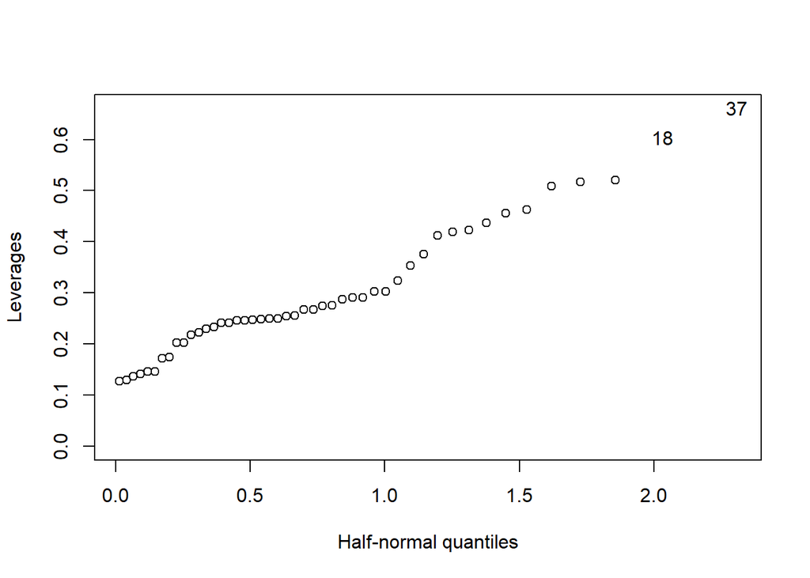

```r
# Prepare a half-normal plot
halfnorm(lev, ylab="Leverages")
```

Observations 18 and 37 are high leverage points. Whether they are good or bad is yet to be decided.

**2.Checking for the presence of outliers**

```r
jackknife=rstudent(model.lm.red)
n = dim(crime)[1]
p = 14
x=qt(.05/(2*n), n-p-1) #Significance level adjusted with Bonferroni's Correction
x
```

```
## [1] -3.59915
```

```r
sort(abs(jackknife),decreasing =T)[1:10]
```

```
##       11       19       29       22       23       46       43       37
## 3.174452 2.984599 2.014265 1.743475 1.730687 1.557610 1.556301 1.509332
##       42       13
## 1.397130 1.322920
```

We can see that there are no outliers in the dataset i.e there are no studentized residual values that are higher (in absolute value) of the critical T distribution value with Bonferroni’s correction.

**3.Checking for the presence of High Influential Points**

To detect high influential points, let’s check the cook’s distance for our model

```r
cook = cooks.distance(model.lm.red)
# Extract max Cook's Distance
max(cook)
```

```
## [1] 0.3059341
```

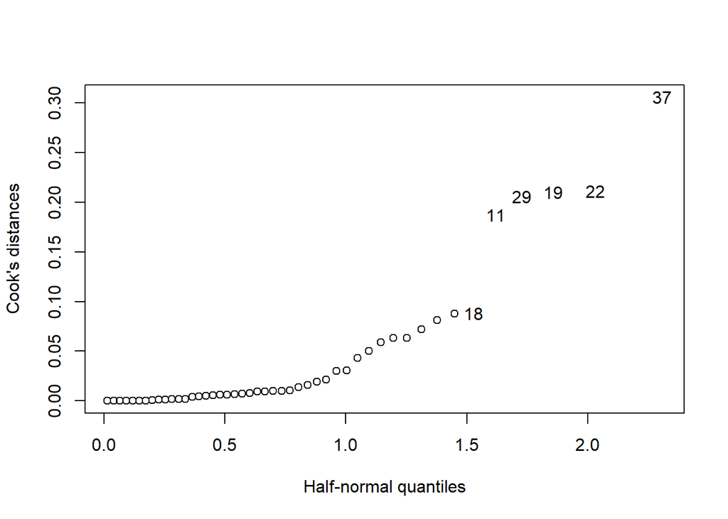

```r
halfnorm(cook, 6, labs=as.character(1:length(cook)), ylab="Cook's distances")
```

From the outputs above, we can see that there no datapoints with a Cook’s distance higher than 1. So, by this rule of thumb we can conclude that there are no high influential points .

#### b) Checking for Model Assumptions :

We also need to see if there are any of the assumptions of our model are being violated.

**1. Checking the constant variance assumption (Homoscedasticity)**

Let’s check if the residuals have constant variance wrt the fitted values in our model

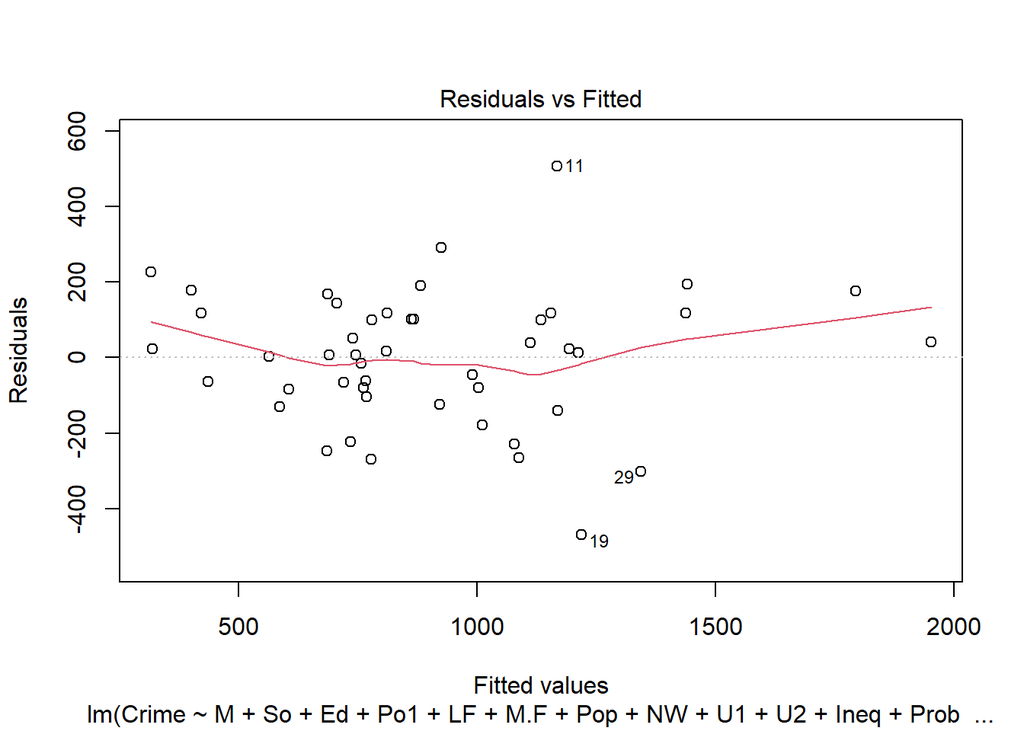

```r
plot(model.lm.red, which=1)
```

We can see that the residuals are more or less randomly distributed from the straight line suggesting that the variance is constant. We can confirm this by performing the Breusch-Pagan test for heteroskedasticity.

```r
bptest(model.lm.red)
```

```
##
##  studentized Breusch-Pagan test
##
## data:  model.lm.red
## BP = 14.359, df = 13, p-value = 0.349
```

The above test checks the below hypotheses :

[
$$\begin{cases}
&H_0: \text{Errors have constant variance}\\
&H_{\alpha}: \text{Errors have non-constant variance}\
\end{cases}$$

]

Since p-value of the test is greater than our significance level of 0.05 , we fail to reject $H_0$ and conclude that the error variance is constant.

**2.Checking the normality of errors assumption**

Let’s check if the errors in our model are normally distributed around a mean of zero. For that, we need to look at the histogram of the residuals as well as the Q-Q plot .

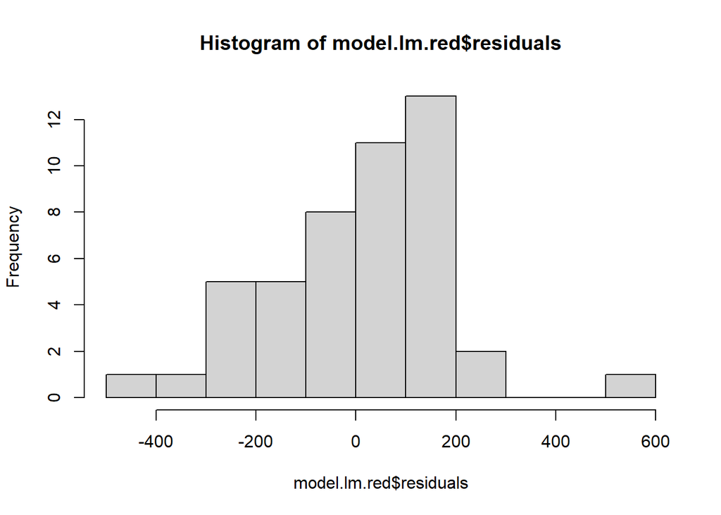

```r
hist(model.lm.red$residuals, breaks = 10)
```

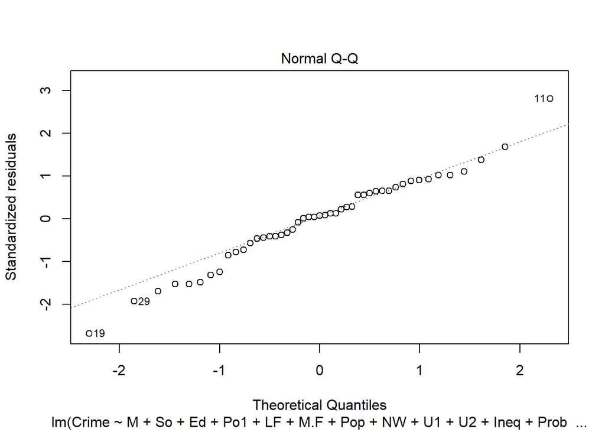

```r
plot(model.lm.red,which = 2)
```

The residuals looks more or less normal from the histogram and the Q-Q plot is also a straight line. The number of observations are less than 50 ( Number of rows in the dataset). So in order to test for normality let’s perform the Shapiro Wilk’s test.

```r
shapiro.test(model.lm.red$residuals)
```

```
##
##  Shapiro-Wilk normality test
##
## data:  model.lm.red$residuals
## W = 0.98041, p-value = 0.6092
```

The above test checks the below hypotheses :

[
$$\begin{cases}
&H_0: \text{Errors are normally distributed }\\
&H_{\alpha}: \text{Errors are not normally distributed}\
\end{cases}$$

]

Since p-value of the test is greater than our significance level of 0.05 , we fail to reject $H_0$ and conclude that the errors are normally distributed.

**3.Checking the linearity assumption**

We can check linearity from the added variable plots of our model

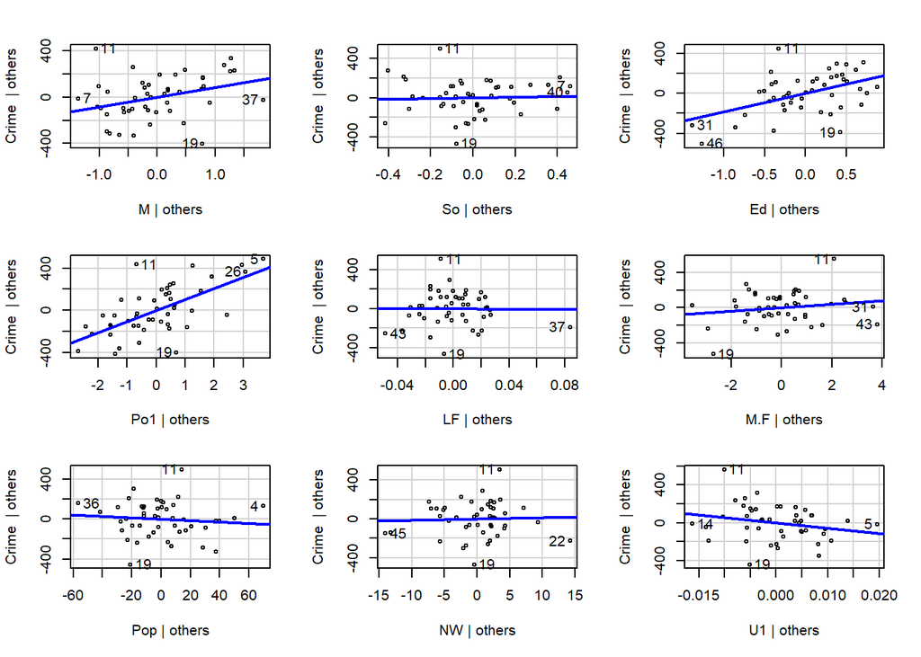

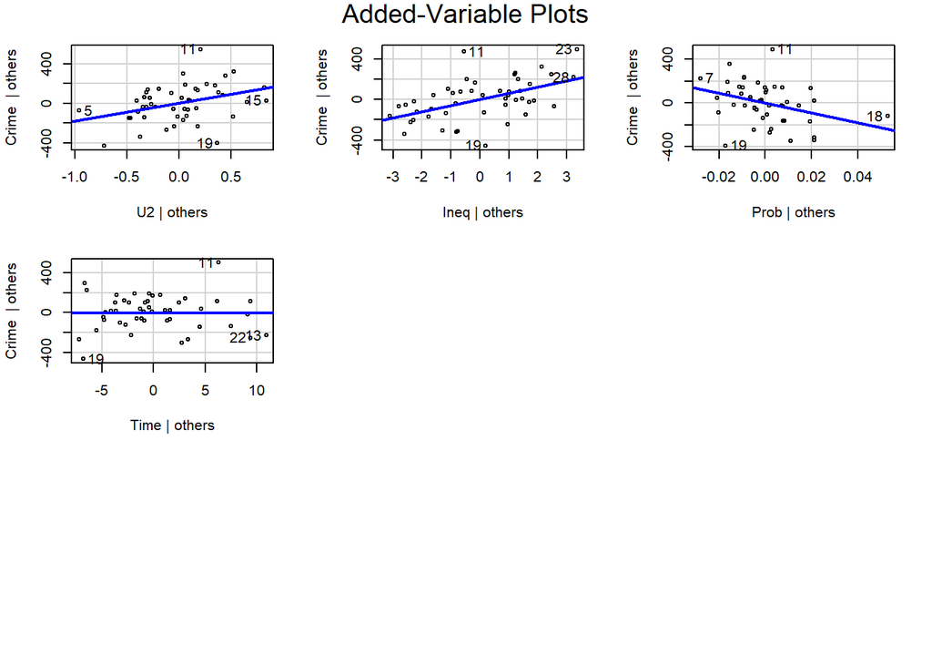

```r
avPlots(model.lm.red)
```

For all the predictors, the added variable plot suggests that the residuals are scattered around a straight line and therefore linearity condition is satisfied and we don’t need to transform any predictor.

## Selecting the Best Model based on prediction accuracy

### Train Test Split

Till now we were checking whether the model assumptions are met and whether there are any unusual points in our dataset. Now our task is select the “best” model to predict the Crime Rate. In order to do that we must first divide our model into two parts -  
a) Train - For training our model  
b) Test - For testing our model and deriving the prediction accuracy (or prediction error)

Before dividing our dataset, let’s drop the two columns from the dataset that we identified were contributing to multicollinearity (`Po2` and `Wealth`)

```r
drop <- c('Po2','Wealth')
crime.new = crime[,!(names(crime) %in% drop)]
names(crime.new)
```

```
##  [1] "M"     "So"    "Ed"    "Po1"   "LF"    "M.F"   "Pop"   "NW"    "U1"
## [10] "U2"    "Ineq"  "Prob"  "Time"  "Crime"
```

Now let’s split our dataset randomly in 70-30 proportion into train and test respectively

```r
# Fix the seed
set.seed(425)

# Train & Test data sets
train_index = sample(seq_len(nrow(crime.new)), size=floor(0.7*nrow(crime.new)))
train = crime.new[train_index,]
test = crime.new[-train_index,]

dim(train)
```

```
## [1] 32 14
```

```r
dim(test)
```

```
## [1] 15 14
```

So there are 32 rows in train and 15 rows in test.

### Fitting a linear model on the training set and obtaining the training and testing errors

Let’s start with a linear model to get the train test errors

```r
lm.crime = lm(Crime ~., data=train)
summary(lm.crime)
```

```
##
## Call:
## lm(formula = Crime ~ ., data = train)
##
## Residuals:
##     Min      1Q  Median      3Q     Max
## -341.84  -93.70    0.25   94.29  307.05
##
## Coefficients:
##               Estimate Std. Error t value Pr(>|t|)
## (Intercept) -7.682e+03  1.712e+03  -4.488 0.000285 ***
## M            2.594e+01  4.762e+01   0.545 0.592658
## So           1.360e+02  1.898e+02   0.716 0.482980
## Ed           2.070e+02  6.716e+01   3.083 0.006418 **
## Po1          1.051e+02  3.009e+01   3.492 0.002602 **
## LF          -1.236e+02  1.664e+03  -0.074 0.941592
## M.F          3.698e+01  2.271e+01   1.628 0.120854
## Pop          4.449e-02  1.458e+00   0.031 0.976000
## NW           5.340e+00  7.063e+00   0.756 0.459408
## U1          -3.329e+03  4.993e+03  -0.667 0.513447
## U2           1.080e+02  1.110e+02   0.972 0.343760
## Ineq         5.539e+01  2.695e+01   2.055 0.054689 .
## Prob        -1.732e+03  2.368e+03  -0.731 0.473988
## Time         1.646e+01  8.123e+00   2.026 0.057845 .
## ---
## Signif. codes:  0 '***' 0.001 '**' 0.01 '*' 0.05 '.' 0.1 ' ' 1
##
## Residual standard error: 194.7 on 18 degrees of freedom
## Multiple R-squared:  0.8603, Adjusted R-squared:  0.7594
## F-statistic: 8.527 on 13 and 18 DF,  p-value: 3.11e-05
```

We have a great $R^2$ of 86% and adjusted $R^2$ of 76%.

Let’s obtain the Train and Test Root Mean Squared Error (RMSE) for the linear model.

```r
lm.train = predict(lm.crime, newdata=train[,-14])
lm.test = predict(lm.crime, newdata=test[,-14])

lm.train.rmse<- rmse(train$Crime, lm.train)
lm.test.rmse<- rmse(test$Crime, lm.test)

print(paste("Linear Model Train RMSE : ",lm.train.rmse))
```

```
## [1] "Linear Model Train RMSE :  146.035391029992"
```

```r
print(paste("Linear Model Test RMSE : ",lm.test.rmse))
```

```
## [1] "Linear Model Test RMSE :  290.55087014071"
```